# Multinomial and Multivariate Normal Models

2014

## The multinomial distribution

The binomial distribution can be generalized to allow for more than two mutually exclusive outcomes. We consider a random variable taking one of of \(k\) possible outcomes and count the number of occurrences of each type of outcome. The vector of such counts, \(y\) has the density \[ p(y|\theta) \propto \prod_{j=1}^k \theta_j^{y_j}~~,~~\sum_{j=1}^k \theta_j = 1. \] We assume that \(\sum_{j=1}^k y_j = n\) is known.

## The Dirichlet distribution

A generalization of the beta distribution to \(k\) components is given by the Dirichlet distribution \[ p(\theta|\alpha) \propto \prod_{j=1}^k \theta_j^{\alpha_j-1}~~,~~ \sum_{j=1}^k \theta_j =1~~,~~\theta_j>0,~ \alpha_j >0,~~ j=1,...,k. \] This distribution is a conjugate prior for the multinomial likelihood. The corresponding posterior distribution is \[ p(\theta|y) \propto \prod_{j=1}^k \theta_j^{\alpha_j + y_j -1}. \] This implies that the posterior distribution is a Dirichlet with parameters \(\alpha_j+y_j~~,~~j=1,\ldots,k\).

## Sampling from a Dirichlet

To obtain a sample from a Dirichlet \(\alpha = (\alpha_1,\ldots,\alpha_k)\), generate \(k\) independent gamma random variates \(x_1,\ldots,x_k\), with shape parameters \(\alpha_1,\ldots,\alpha_k\). Let \[ \theta_j = \frac{x_j}{\sum_{j=1}^k x_j}. \] We notice that the scale that is used to generate the gamma variates is irrelevant, as it cancels in the ratio.

Here we can define a function to do that in R:

```r
# a is a vector of alphas
rdirch.one <- function(a) {
  x <- rgamma(length(a), a)
  x/sum(x)
}
```

## Sampling from a Dirichlet

### (a vectorized version)

Of course, if we want multiple replicates of \(\theta\) we would want to pass it an `n` argument too. In that case, we can make a nice vectorized version like this:

```r
rdirch <- function(n = 1, a) {
  x <- matrix(rgamma(n * length(a), a), nrow = length(a))
  denoms <- colSums(x)
  x/rep(denoms, each = length(a))
}
```

which returns random vectors as columns in a matrix. Here is an example:

```r
set.seed(10)
rdirch(5, c(1,5,10))
```

```
##         [,1]    [,2]    [,3]    [,4]    [,5]
## [1,] 0.04296 0.05966 0.02579 0.01431 0.03784
## [2,] 0.34459 0.43844 0.26878 0.35929 0.18092
## [3,] 0.61245 0.50190 0.70542 0.62640 0.78124
```

## Sampling From a Dirichlet

### (plotted results)

Here we make boxplots of the components of 1000 random vectors:

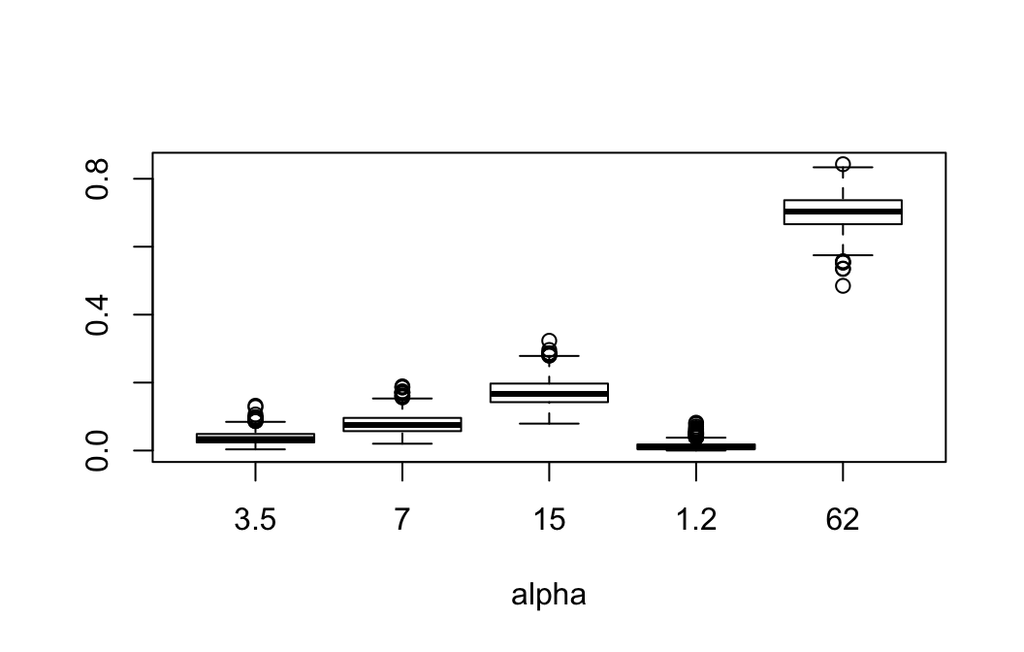

```r
alpha <- c(3.5, 7, 15, 1.2, 62)
x <- rdirch(1000, a = alpha)
boxplot(as.numeric(x) ~ factor(rep(alpha, length.out = length(x)), levels = alpha),
        xlab = "alpha")
```